# LOVER OF WISDOM

Jessie Yu (UNI:jy3161)

## 0. Install and Load Libraries

```r
library(tm)
library(wordcloud)
library(RColorBrewer)
library(dplyr)
library(tidytext)
library(stringr)
library(ggplot2)
library(sentimentr)
library(ggpubr)
```

This notebook was prepared with the following environmental settings.

```
##                _
## platform       x86_64-apple-darwin17.0
## arch           x86_64
## os             darwin17.0
## system         x86_64, darwin17.0
## status
## major          4
## minor          0.3
## year           2020
## month          10
## day            10
## svn rev        79318
## language       R
## version.string R version 4.0.3 (2020-10-10)
## nickname       Bunny-Wunnies Freak Out
```

## 1.About the data

Hang on to the interesting discoveries for a second! Let’s first take a look at the dataset!

```r
head(philosophy)
```

```
## # A tibble: 6 × 11
##   title   author school sentence_spacy       sentence_str       original_public…
##   <chr>   <chr>  <chr>  <chr>                <chr>                         <dbl>
## 1 Plato … Plato  plato  What's new, Socrate… What's new, Socra…             -350
## 2 Plato … Plato  plato  Surely you are not … Surely you are no…             -350
## 3 Plato … Plato  plato  The Athenians do no… The Athenians do …             -350
## 4 Plato … Plato  plato  What is this you sa… What is this you …             -350
## 5 Plato … Plato  plato  Someone must have i… Someone must have…             -350
## 6 Plato … Plato  plato  But someone else ha… But someone else …             -350
## # … with 5 more variables: corpus_edition_date <dbl>, sentence_length <dbl>,
## #   sentence_lowered <chr>, tokenized_txt <chr>, lemmatized_str <chr>
```

Checking for NAs:

```r
sum(is.na(philosophy) == "TRUE")
```

```
## [1] 0
```

Now, let’s get a sense of the length of sentences said by philosophers in each School. Here, I used the pre-processed and pre-defined value in the original dataset, the tokenized texts, and create a new variable that corresponding to the length of the sentences, number of words.

```r
# add new column: number of tokens
philosophy$`n_tokens` <- str_count(philosophy$tokenized_txt, "\\w+")
```

Using data visualization to discover the length of sentences by School:

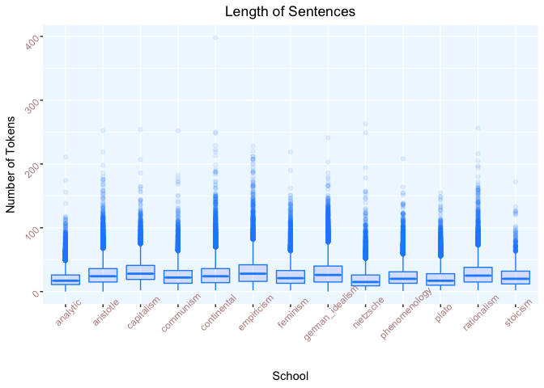

```r
ggplot(data = philosophy, aes(x = school, y = n_tokens)) +
  geom_boxplot(color="dodgerblue", fill="blue", alpha=0.1, notch=TRUE, notchwidth = 0.9) +
  theme(axis.text.x = element_text(color = "rosybrown",
                           size = 9, angle = 45),
          axis.text.y = element_text(color = "rosybrown",
                           size = 9, angle = 45),
        plot.title = element_text(hjust = 0.5),
        panel.background = element_rect(fill = "aliceblue")) +
  ggtitle("Length of Sentences") + xlab("School") + ylab("Number of Tokens")
```

```r
as.data.frame(philosophy %>%
    group_by(school,author,title) %>%
    count(title)) %>%
    arrange(desc(n))
```

```
##             school          author
## 1        aristotle       Aristotle
## 2            plato           Plato
## 3         analytic           Lewis
## 4         feminism        Beauvoir
## 5      rationalism     Malebranche
## 6        communism            Marx
## 7       capitalism           Smith
## 8  german_idealism           Hegel
## 9         analytic          Kripke
## 10   phenomenology       Heidegger
## 11     continental        Foucault
## 12      empiricism           Locke
## 13   phenomenology   Merleau-Ponty
## 14 german_idealism            Kant
```

[output cut: 105 more lines]

## 2. The Word Clouds ‘Collection’

Let’s dig in more!!

I explored the data by unnesting the tokenized text and removing the less meaningful words, removing the stopwords in English, and generated word frequency tables.

**Which words were most frequently used by these philosophers ?**

Check out this *Overall Wordcloud* !

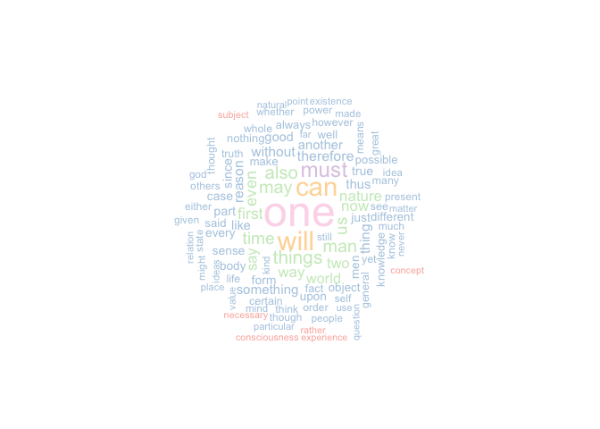

```r
overall.words <- philosophy %>%
  select(tokenized_txt) %>%
  unnest_tokens(words, tokenized_txt, token = "words") %>%
  filter(!(words %in% stopwords("English"))) %>%
  count(words, sort = TRUE)

wordcloud(overall.words$words, overall.words$n,
          scale=c(3,0.35),
          max.words=100,
          min.freq=1,
          random.order=FALSE,
          rot.per=0.25,
          use.r.layout=T,
          random.color=FALSE,
          colors=brewer.pal(8,"Pastel1"))
```

It is worth noticing after removing the stopwords, the most frequently used words by the philosophers is ‘ONE’, and also other words “can”, “will”, “must”…

Now, let us get a closer look and focus on each School!

Word clouds by School(ordered by the amount of sentences from high to low):

Notice: here I only present one chunk of code to demonstrate the coding for first three school’s word cloud, more details can be found on my [Github Page](https://github.com/TZstatsADS/spring-2022-prj1-JessieYu3161).

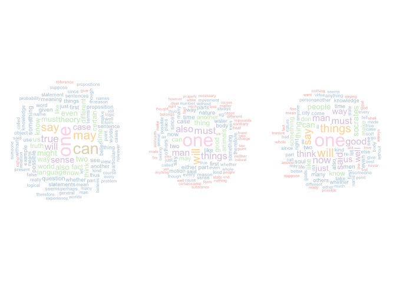

```r
par(mfrow= c(1,3), mar = c(1,1,1,1))

analytic.words <- philosophy %>%
  filter(school == "analytic") %>%
  select(tokenized_txt) %>%
  unnest_tokens(words, tokenized_txt, token = "words") %>%
  filter(!(words %in% stopwords("English"))) %>%
  count(words, sort = TRUE)


analytic.wc <- wordcloud(analytic.words$words, analytic.words$n,
          scale=c(3,0.35),
          max.words=100,
          min.freq=1,
          random.order=FALSE,
          rot.per=0.25,
          use.r.layout=T,
          random.color=FALSE,
          colors=brewer.pal(8,"Pastel1"))

aristotle.words <- philosophy %>%
  filter(school == "aristotle") %>%
  select(tokenized_txt) %>%
  unnest_tokens(words, tokenized_txt, token = "words") %>%
  filter(!(words %in% stopwords("English"))) %>%
  count(words, sort = TRUE)


aristotle.wc <- wordcloud(aristotle.words$words, aristotle.words$n,
          scale=c(3,0.35),
          max.words=100,
          min.freq=1,
          random.order=FALSE,
          rot.per=0.25,
          use.r.layout=T,
          random.color=FALSE,
          colors=brewer.pal(8,"Pastel1"))

plato.words <- philosophy %>%
  filter(school == "plato") %>%
  select(tokenized_txt) %>%
  unnest_tokens(words, tokenized_txt, token = "words") %>%
  filter(!(words %in% stopwords("English"))) %>%
  count(words, sort = TRUE)


wordcloud(plato.words$words, plato.words$n,
          scale=c(3,0.35),
          max.words=100,
          min.freq=1,
          random.order=FALSE,
          rot.per=0.25,
          use.r.layout=T,
          random.color=FALSE,
          colors=brewer.pal(8,"Pastel1"))
```

Analytic, Aristotle , and Plato Word Clouds

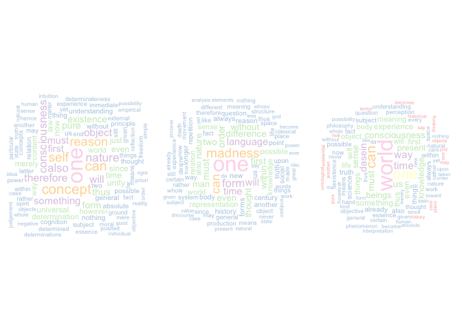

German Idealism, Continental, and Phenomenology Word Cloud

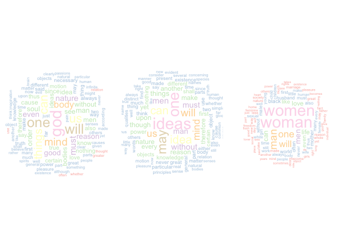

Rationalism, Empiricism, and Feminism Word Cloud

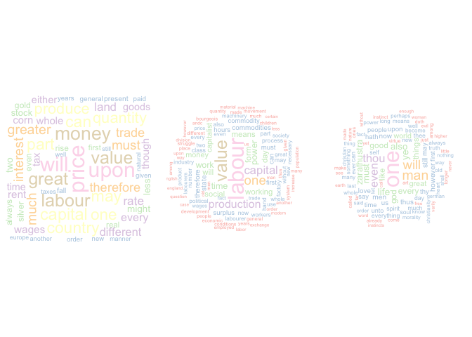

Capitalism, Communism, and Nietzsche Word Cloud

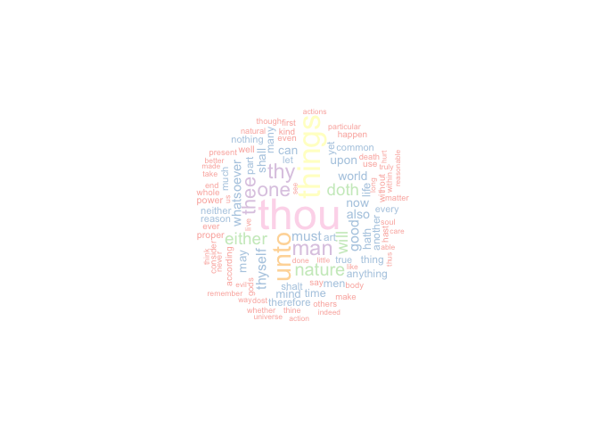

Stoicism Word Cloud

It is interesting to see Rationalism most frequently used word is “GOD”, “the rationalists discovered God through the natural world, but in a different way. Rationalists thought it unlikely that God would choose to reveal himself only at particular times to particular people.” If you take a look at the Feminism, Capitalism, and Communism Word Cloud, these are rather intuitional and congenital.

## 3. Sentiment Analysis

For sentiment analysis in this section, I’m using NRC Word-Emotion Association Lexicon, *more details can be found here* [NRC_Lexicon](http://saifmohammad.com/WebPages/NRC-Emotion-Lexicon.htm).

Let’s first look at Plato, Aristotle, and Nietzsche, who are the only author corresponding to each school in our dataset!

```
## # A tibble: 3 × 1
##   author
##   <chr>
## 1 Plato
## 2 Aristotle
## 3 Nietzsche
```

Here, I calculated the frequency of each sentimental words used by each author and assign colors by sentiment type. Notice that I filtered out “positive” and “negative” categories in the sentiment types, we focus on emotions here (anger, anticipation, disgust, fear, joy, sadness, surprise, and trust).

```r
plato.sentiment <- plato.words %>%
  rename(word = words) %>%
  left_join(get_sentiments("nrc"), by = "word") %>%
  mutate(sentiment = factor(sentiment)) %>%
  filter(is.na(sentiment) == F) %>%
  group_by(sentiment) %>%
  summarise(sentiment_freq =sum(n))

plato.s.p <- plato.sentiment %>% filter(sentiment != "positive", sentiment != "negative") %>%
  ggplot(aes(sentiment, sentiment_freq, fill = sentiment)) +
  geom_bar(stat="identity",
           position=position_dodge()) +
  theme_bw() +
  theme(legend.position = "top",
        axis.text.x = element_text(color = "rosybrown",
                           size = 9, angle = 45),
          axis.text.y = element_text(color = "rosybrown",
                           size = 9, angle = 45),
        plot.title = element_text(hjust = 0.5),
        panel.background = element_rect(fill = "aliceblue")) +
  xlab("Sentiment") + ylab("Frequency")
```

```r
aristotle.sentiment <- aristotle.words %>%
  rename(word = words) %>%
  left_join(get_sentiments("nrc"), by = "word") %>%
  mutate(sentiment = factor(sentiment)) %>%
  filter(is.na(sentiment) == F) %>%
  group_by(sentiment) %>%
  summarise(sentiment_freq =sum(n))

aristotle.s.p <- aristotle.sentiment %>% filter(sentiment != "positive", sentiment != "negative") %>%
  ggplot(aes(sentiment, sentiment_freq, fill = sentiment)) +
  geom_bar(stat="identity",
           position=position_dodge()) +
  theme_bw() +
  theme(legend.position = "top",
        axis.text.x = element_text(color = "rosybrown",
                           size = 9, angle = 45),
          axis.text.y = element_text(color = "rosybrown",
                           size = 9, angle = 45),
        plot.title = element_text(hjust = 0.5),
        panel.background = element_rect(fill = "aliceblue")) +
 xlab("Sentiment") + ylab("Frequency")
```

```r
nietzsche.sentiment <- nietzsche.words %>%
  rename(word = words) %>%
  left_join(get_sentiments("nrc"), by = "word") %>%
  mutate(sentiment = factor(sentiment)) %>%
  filter(is.na(sentiment) == F) %>%
  group_by(sentiment) %>%
  summarise(sentiment_freq =sum(n))

nietzsche.s.p <- nietzsche.sentiment %>% filter(sentiment != "positive", sentiment != "negative") %>%
  ggplot(aes(sentiment, sentiment_freq, fill = sentiment)) +
  geom_bar(stat="identity",
           position=position_dodge()) +
  theme_bw() +
  theme(legend.position = "top",
        axis.text.x = element_text(color = "rosybrown",
                           size = 9, angle = 45),
          axis.text.y = element_text(color = "rosybrown",
                           size = 9, angle = 45),
        plot.title = element_text(hjust = 0.5),
        panel.background = element_rect(fill = "aliceblue")) +
  xlab("Sentiment") + ylab("Frequency")
```

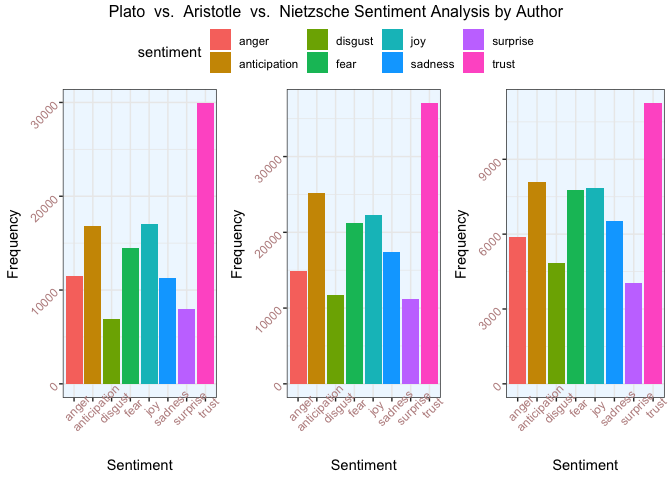

```r
s.p <- ggarrange(plato.s.p, aristotle.s.p, nietzsche.s.p, ncol = 3, nrow = 1, common.legend = TRUE)
annotate_figure(s.p, top = text_grob("Plato  vs.  Aristotle  vs.  Nietzsche Sentiment Analysis by Author"))
```

As for the rest of the school, each school has multiple number of authors. Let’s compare them! For a more intuitive and informative perception, I calculated the percentage of each sentimental words used by each author. Colors are assigned based on sentiment types.

Notice: The coding for each school is repetitive and here I would only show Analytic school for demonstration, for more details [Github Page](https://github.com/TZstatsADS/spring-2022-prj1-JessieYu3161).

```r
analytic.sentiment <- philosophy %>%
  filter(school == "analytic") %>%
  select(author,tokenized_txt) %>%
  unnest_tokens(words, tokenized_txt, token = "words") %>%
  filter(!(words %in% stopwords("English"))) %>%
  rename(word = words) %>%
  group_by(author) %>%
  mutate(n_words = n()) %>%
  left_join(get_sentiments("nrc"), by = "word") %>%
  mutate(sentiment = factor(sentiment)) %>%
  filter(is.na(sentiment) == F) %>%
  group_by(sentiment, author, n_words) %>%
  summarise(sentiment_freq = n()) %>%
  mutate(percentage = round(sentiment_freq/n_words*100, 1))

analytic.s.p <- analytic.sentiment %>% filter(sentiment != "positive", sentiment != "negative") %>%
  ggplot(aes(author, percentage, fill = sentiment)) +
  geom_bar(stat="identity",
           position=position_dodge()) +
  scale_fill_brewer(palette="Pastel1") +
  theme_bw() +
  theme(legend.position = "top",
        axis.text.x = element_text(color = "rosybrown",
                           size = 9, angle = 45),
          axis.text.y = element_text(color = "rosybrown",
                           size = 9, angle = 45),
        plot.title = element_text(hjust = 0.5),
        panel.background = element_rect(fill = "aliceblue")) +
   ggtitle("Analytic Sentiment Analysis") + xlab("Authors") + ylab("Percentage")
```

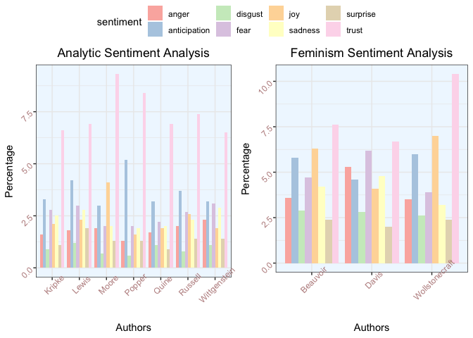

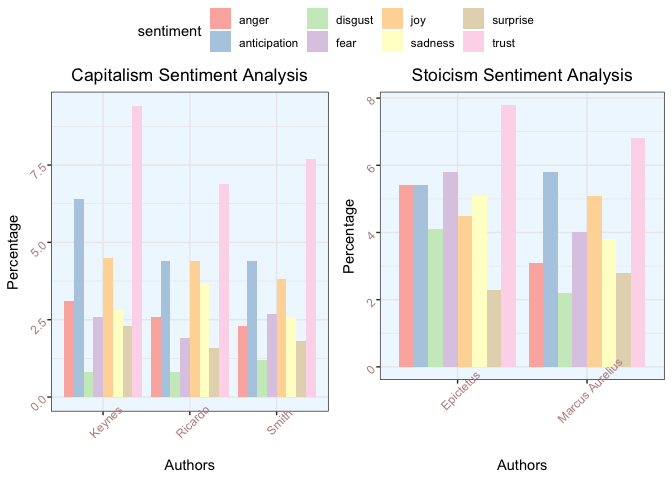

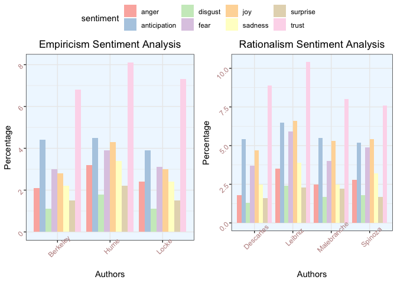

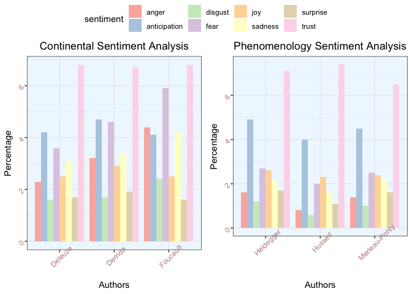

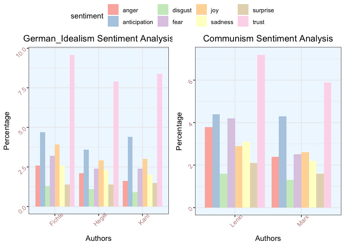

```r
ggarrange(analytic.s.p, feminism.s.p, ncol = 2, nrow = 1, common.legend = TRUE)
```

As the above visualizations present, “trust” words are indeed popular!!! “Trust” words are defined as “Positive” sentiment and they are a big deal to philosophers.

Curious about what “trust” words are used?

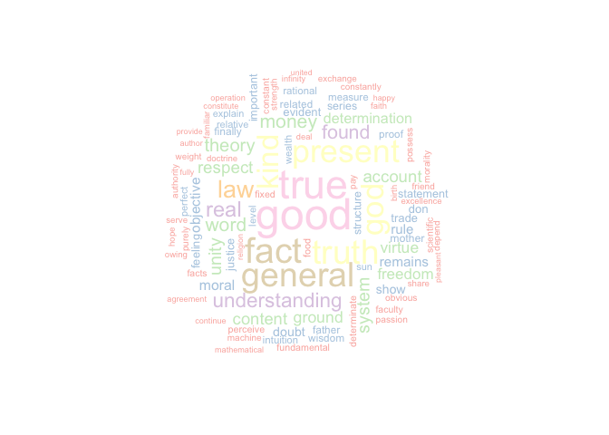

```r
trust <- overall.words %>%
  rename(word = words) %>%
  left_join(get_sentiments("nrc"), by = "word") %>%
  mutate(sentiment = factor(sentiment)) %>%
  filter(is.na(sentiment) == F, sentiment == "trust")

wordcloud(trust$word, trust$n,
          scale=c(3,0.35),
          max.words=100,
          min.freq=1,
          random.order=FALSE,
          rot.per=0.25,
          use.r.layout=T,
          random.color=FALSE,
          colors=brewer.pal(8,"Pastel1"))
```